# Hausarbeit Maschinelles Lernen MADS23oB Heidi Gehring, Lea Kleemann

## Eidesstattliche Erklärung

Hiermit versichere ich, dass ich die vorliegende akademische Abschlussarbeit selbstständig und ohne fremde Hilfe angefertigt habe.  
Alle Textstellen, die ich wörtlich oder sinngemäß aus veröffentlichten oder nicht veröffentlichten Quellen übernommen habe, wurden von mir als solche gekennzeichnet.

Heidi Gehring

Lea Kleemann

## Problem Statement

### Dataset for the analysis

In this assignment the [following](https://www.kaggle.com/datasets/thedevastator/book-recommender-system-itembased?select=collaborative_books_df.csv) Dataset is used. It was initially suggested to be used to create a recommender system for books.

### Focus of the analysis

In this assignment it will be evaluated whether the available information is suitable to predict how a given user would rate a specific book.

### Link to the Repository

The Github repsitory that was used for this assignment can be found [here](https://github.com/LeaKleemann/HA_MaschinellesLernen_MADS23oB)

This notebook was executed in Python 3.8.x, because of the tensorflow dependency. Some code was originally written and executed in Python 3.12.x.

## Solution approach and project outline

The objective of this assignment is to train a model that is able to predict the rating of a book by a given user analogue to the "Predicted Rating" in the file "collaborative_books_df.csv". It is not the objective to create a book recommender system.

Throughout the assignment, both classification as well as regression algomrithms and methods will be used to analyse the use case. The "Actual Ratings" are used as the target variable. As can be seen both as a finite number of categories as well as numeric values, the previous mentioned algorithms seem suitable.

This assignment is based on the initial hyptheses, that the users can be clustered into well separated groups based on what they are reading and how they are rating those books. It was the plan that those clusters shall then be used as feature input for the prediction modells for the ratings.

Additionally, some metadata about the books needs to be transformed. The focus was on the features "description" which is the blurbs of the books as well as the genres, where each book is mapped to 1 or more genres. For the blurbs, topic modeling approaches are being explored, for the genres the one-hot-encoding is being used.

## Data exploration

```python
# combining all imports for the notebook
import pandas as pd
import matplotlib.pyplot as plt
from mpl_toolkits.mplot3d import Axes3D
import seaborn as sns
import pathlib2 as pathlib
import numpy as np

from gensim.models.coherencemodel import CoherenceModel
import gensim.corpora as corpora
from gensim.parsing.preprocessing import STOPWORDS
from gensim.utils import tokenize
import re

import joblib
from optuna import Trial, create_study
from optuna.pruners import SuccessiveHalvingPruner

from sklearn.pipeline import Pipeline

from sklearn.preprocessing import MultiLabelBinarizer
from sklearn.preprocessing import normalize
from sklearn.preprocessing import StandardScaler
from sklearn.preprocessing import PolynomialFeatures

from sklearn.decomposition import LatentDirichletAllocation
from sklearn.decomposition import NMF
from sklearn.decomposition import PCA

from sklearn.feature_extraction.text import TfidfVectorizer, CountVectorizer

from sklearn.model_selection import train_test_split
from sklearn.model_selection import cross_val_score, KFold
from sklearn.model_selection import RandomizedSearchCV
from sklearn.model_selection import GridSearchCV

from sklearn.impute import SimpleImputer

from sklearn.cluster import KMeans
from sklearn.cluster import DBSCAN

from sklearn.linear_model import LinearRegression
from sklearn.linear_model import Lasso, Ridge
from sklearn.feature_selection import RFE

from sklearn.ensemble import RandomForestRegressor

from sklearn.neighbors import KNeighborsRegressor
from sklearn.neighbors import NearestNeighbors

from sklearn.metrics import mean_squared_error, r2_score
from sklearn.metrics import make_scorer
from sklearn.metrics import accuracy_score
from sklearn.metrics import silhouette_score
from sklearn.metrics import adjusted_rand_score

from sklearn import svm
from sklearn.svm import SVC
from sklearn.tree import DecisionTreeRegressor
from sklearn.tree import DecisionTreeClassifier

from sklearn.neural_network import MLPRegressor

import tensorflow as tf

randomstate=313

# treat all python warnings as lower-level "ignore" events
import warnings
warnings.filterwarnings("ignore")
```

```python
# define base paths
cwd=pathlib.Path.cwd() #current working directory
datadirpath=cwd.joinpath("data") # data drectory unter current working directory
rawdatapath=datadirpath.joinpath("raw")
```

# Explore collaborative_books_df.csv

```python
reviewdf=pd.read_csv(rawdatapath.joinpath("collaborative_books_df.csv"))
reviewdf=reviewdf.drop([reviewdf.columns[0]],axis=1) # removed unnamed index column
print(reviewdf.columns)
```

```
Index(['title', 'book_id', 'user_id_mapping', 'book_id_mapping',
       'Predicted Rating', 'Actual Rating'],
      dtype='object')
```

```python
# print basic information
print(f"Number of observations: {len(reviewdf)}")
print(f"Number of unique book ids: {len(reviewdf['book_id'].unique())}")
print(f"Number of unique user ids: {len(reviewdf['user_id_mapping'].unique())}")
print(f"Average actual rating: {reviewdf['Actual Rating'].mean()}")
print(f"Average predicted rating: {reviewdf['Predicted Rating'].mean()}")
```

```
Number of observations: 196296
Number of unique book ids: 898
Number of unique user ids: 66909
Average actual rating: 3.922902147776827
Average predicted rating: 3.8966672779883433
```

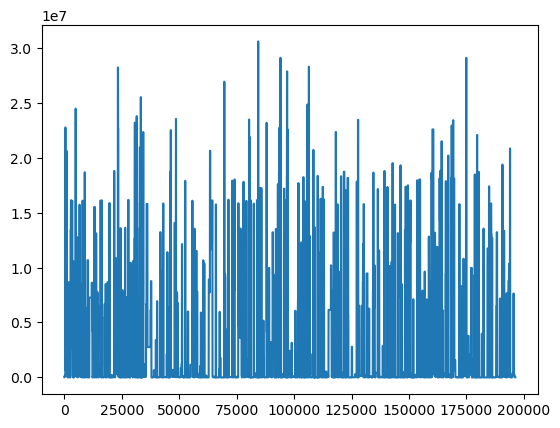

```python
reviewdf["book_id"].plot() # not conclusive, try grouped by id, count as aggregate metric
```

```python
num_books=len(reviewdf.book_id_mapping.unique())
print(f'Number of unique books: {num_books}') #898 --> that means we do not have data for all books
```

```
Number of unique books: 898
```

## Explore user ids

```python
# groupby user id
reviewdf_userids=reviewdf[["user_id_mapping","book_id"]].groupby(by="user_id_mapping").count()
reviewdf_userids=reviewdf_userids.reset_index()
reviewdf_userids=reviewdf_userids.rename(columns={"book_id":"book_count"})
```

```python
print(f"(repeat) Number of users: {len(reviewdf_userids)}")
print(f"Max number of books revied per user: {reviewdf_userids.book_count.max()}")
print(f"Min number of books revied per user: {reviewdf_userids.book_count.min()}")
print(f"Number of users with 1 review: {len(reviewdf_userids.query('book_count == 3'))}")
print(f"... in %: {round(len(reviewdf_userids.query('book_count == 3'))/len(reviewdf_userids),2)*100}%") # 18% is suboptimal --> prediction of score for single user is probably not going to work
print(f"Number of users with less than 6 reviews: {len(reviewdf_userids.query('book_count < 6'))}")
print(f"... in %: {round(len(reviewdf_userids.query('book_count < 6'))/len(reviewdf_userids),2)*100}%") # 90% is suboptimal
```

[output not shown]

## Explore book ids

```python
# groupby book_id
reviewdf_bookids=reviewdf[["book_id","user_id_mapping"]].groupby(by="book_id").count()
reviewdf_bookids=reviewdf_bookids.reset_index()
reviewdf_bookids=reviewdf_bookids.rename(columns={"user_id_mapping":"user_count"})
```

```python
print(f"(repeat) Number of books: {len(reviewdf_bookids)}")
print(f"Max number of users reviewd per book: {reviewdf_bookids.user_count.max()}")
print(f"Min number of users reviewd per book: {reviewdf_bookids.user_count.min()}")
print(f"Number of books with 1 review: {len(reviewdf_bookids.query('user_count == 3'))}")
print(f"... in %: {round(len(reviewdf_bookids.query('user_count == 3'))/len(reviewdf_bookids),2)*100}%") # 18% is suboptimal --> prediction of score for single user is probably not going to work
print(f"Number of books with less than 6 reviews: {len(reviewdf_bookids.query('user_count < 6'))}")
print(f"... in %: {round(len(reviewdf_bookids.query('user_count < 6'))/len(reviewdf_bookids),2)*100}%") # 90% is suboptimal
```

```
(repeat) Number of books: 898
Max number of users reviewd per book: 1296
Min number of users reviewd per book: 36
Number of books with 1 review: 0
... in %: 0.0%
Number of books with less than 6 reviews: 0
... in %: 0.0%
```

## Explore Ratings

```python
reviewvaluecountsdf=reviewdf["Actual Rating"].value_counts()
reviewssum=reviewvaluecountsdf.sum()
reviewvaluecountsdf["percentage"]=reviewvaluecountsdf.transform(func=lambda x:x/reviewssum*100,axis=0) #50+% at rating of more than 3

predvaluecountsdf=reviewdf["Predicted Rating"].value_counts()
predvaluecountsdf["percentage"]=predvaluecountsdf.transform(func=lambda x:x/reviewssum*100,axis=0)

bins=[1,2,3,4,5,6] #
hist, edges = np.histogram(reviewdf["Predicted Rating"],bins=bins,density=False)
predbinsvaluecountsdf=pd.DataFrame(hist,index=bins[:-1],columns=["PredictedRating_count"])
predbinsvaluecountsdf["percentage"]=predbinsvaluecountsdf.transform(func=lambda x:x/reviewssum*100,axis=0)
```

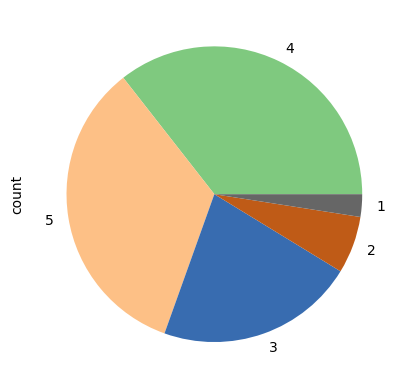

```python
reviewvaluecountsdf["percentage"].plot(kind='pie',colormap='Accent')
```

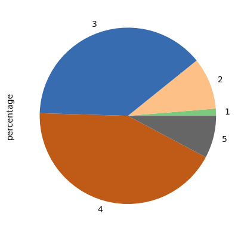

```python
predbinsvaluecountsdf.percentage.plot(kind='pie',colormap='Accent')
```

```python
print(f"Sum of reviews: {reviewssum}")

print(f"(repeat) Average actual rating: \n {reviewdf['Actual Rating'].mean()}")
print(f"Max actual rating: {reviewdf['Actual Rating'].max()}")
print(f"Min actual rating: {reviewdf['Actual Rating'].min()}")
print(f"Overview of Rating occurence: {reviewvaluecountsdf}")
print(f"... in percentage: \n {reviewvaluecountsdf['percentage']}") # comparatively few bad reviews
print("________________ \n")
print(f"(repeat) Average predicted rating: {reviewdf['Predicted Rating'].mean()}")
print(f"Max predicted rating: {reviewdf['Predicted Rating'].max()}")
print(f"Min predicted rating: {reviewdf['Predicted Rating'].min()}")
# print(f"Overview of Rating occurence: {predvaluecountsdf}") # continuous values
# print(f"... in percentage: \n {predvaluecountsdf["percentage"]}") # continuous values, try binning
print(f"Overview of Rating occurence: \n {predbinsvaluecountsdf['PredictedRating_count']}")
print(f"... in percentage: \n {predbinsvaluecountsdf['percentage']}")
```

```
Sum of reviews: 196296
(repeat) Average actual rating:
 3.922902147776827
Max actual rating: 5
Min actual rating: 1
Overview of Rating occurence: Actual Rating
4                                                         69813
5                                                         66663
3                                                         42680
2                                                         12303
1                                                          4837
percentage    Actual Rating
4    35.565167
5    33.960447
3 ...
Name: count, dtype: object
... in percentage:
 Actual Rating
4    35.565167
5    33.960447
3    21.742674
2     6.267575
1     2.464136
Name: count, dtype: float64
________________

(repeat) Average predicted rating: 3.8966672779883433
Max predicted rating: 5.0
Min predicted rating: 1.0
Overview of Rating occurence:
 1     2588
2    18588
3    76042
4    83816
5    15262
Name: PredictedRating_count, dtype: int64
... in percentage:
 1     1.318417
2     9.469373
3    38.738436
4    42.698781
5     7.774993
Name: percentage, dtype: float64
```

# exploring collaborative_book_metadata.csv

```python
booksdf=pd.read_csv(rawdatapath.joinpath('collaborative_book_metadata.csv'))
booksdf=booksdf.drop([booksdf.columns[0]],axis=1) # removed unnamed index column
print(booksdf.columns)
booksgroupbyauthorsdf=booksdf[["name","book_id_mapping"]].groupby(by="name").count()
booksgroupbyauthorsdf=booksgroupbyauthorsdf.reset_index()
booksgroupbyauthorsdf=booksgroupbyauthorsdf.rename(columns={"book_id_mapping":"book_count"})
```

```
Index(['book_id', 'title', 'image_url', 'url', 'num_pages', 'ratings_count',
       'description', 'genre', 'name', 'book_id_mapping'],
      dtype='object')
```

```python
booksgroupbyauthorsdf.sort_values(by="book_count",ascending=False).head()
```

|  | name | book_count |
| --- | --- | --- |
| 7 | Charlaine Harris | 3 |
| 21 | Fiona Staples | 3 |
| 11 | Christopher Paolini | 3 |
| 22 | George R.R. Martin | 2 |
| 67 | Robert Jordan | 2 |

```python
print(f"Number of books: {len(booksdf)}")
print("___________________ \n")
print(f"Max number of pages: {booksdf.num_pages.max()}")
print(f"Avg number of pages: {booksdf.num_pages.mean()}")
print(f"Min number of pages: {booksdf.num_pages.min()}")
print("___________________ \n")
print(f"Max number of ratings: {booksdf.ratings_count.max()}")
print(f"Avg number of ratings: {booksdf.ratings_count.mean()}")
print(f"Min number of ratings: {booksdf.ratings_count.min()}")
print("___________________ \n")
print(f"Number of unique authors: {len(booksdf.name.unique())}")
print(f"Authors with most books: {booksgroupbyauthorsdf.sort_values(by='book_count',ascending=False).head()}") #max =3, not al lot of books per author, maybe not predictive enough
```

```
Number of books: 96
___________________

Max number of pages: 4100
Avg number of pages: 388.96875
Min number of pages: 26
___________________

Max number of ratings: 1128913
Avg number of ratings: 235801.38541666666
Min number of ratings: 50020
___________________

Number of unique authors: 83
Authors with most books:                    name  book_count
7      Charlaine Harris           3
21        Fiona Staples           3
11  Christopher Paolini           3
22   George R.R. Martin           2
67        Robert Jordan           2
```

## explore genres

```python
# split and process genres
booksdf['genre']=booksdf.genre.apply(lambda x: x.replace("'","")) # remove '
booksdf['genre']=booksdf.genre.apply(lambda x: x.replace("-","")) # revome -
booksdf['genre']=booksdf.genre.apply(lambda x: x.replace(" ","")) # remove spaces
booksdf['genre']=booksdf.genre.apply(lambda x: x[1:-1].split(',')) # split into list
```

```python
# get number of genres
booksdf["num_genres"]=booksdf.genre.apply(lambda x: len(x))
```

```python
print(f"Max number of genres: {booksdf.num_genres.max()}")
print(f"Avg number of genres: {booksdf.num_genres.mean()}")
print(f"Min number of genres: {booksdf.num_genres.min()}")
```

```
Max number of genres: 12
Avg number of genres: 5.760416666666667
Min number of genres: 1
```

```python
flattenedgenres=[g for sub in booksdf.genre.to_list() for g in sub]
uniquegenres=list(set(flattenedgenres))
```

```python
print(uniquegenres)
print(f"Number of unique genres: {len(uniquegenres)}") # 16 genres: maybe too many --> sparse
```

```
['biography', 'fantasy', 'thriller', 'youngadult', 'poetry', 'crime', 'graphic', 'children', 'nonfiction', 'comics', 'historicalfiction', 'history', 'mystery', 'fiction', 'romance', 'paranormal']
Number of unique genres: 16
```

```python
# encode genres
booksdf=booksdf.join(booksdf.genre.str.join('|').str.get_dummies())
```

```python
genressum=booksdf[uniquegenres].sum()
genressum
```

```
biography            23
fantasy              60
thriller             28
youngadult           66
poetry                5
crime                28
graphic              14
children             20
nonfiction           16
comics               14
historicalfiction    23
history              23
mystery              28
fiction              92
romance              53
paranormal           60
dtype: int64
```

```python
print(f"Max amount of books in genre: {genressum.max()}") # fiction, with 96 books total and 16 nonfiction? are there fiction/nonfiction books?
print(f"Avg amount of books in genre: {genressum.mean()}")
print(f"Min amount of books in genre: {genressum.min()}") # poetry only has 5 books, could be underrepresented
```

```
Max amount of books in genre: 92
Avg amount of books in genre: 34.5625
Min amount of books in genre: 5
```

```python
contradictorygenresdf=booksdf[(booksdf['nonfiction']==1) & (booksdf['fiction']==1)]
```

```python
print(f"Number of books both fiction and nonfiction: {len(contradictorygenresdf)}") # 12, consider removing fiction-genre?
```

```
Number of books both fiction and nonfiction: 12
```

## Join books_df (reviews) with book_metadata (books)

```python
joinedouterdf=pd.merge(reviewdf,booksdf,left_on='book_id_mapping',right_on='book_id_mapping',how='outer')
joinedinnerdf=pd.merge(reviewdf,booksdf,left_on='book_id_mapping',right_on='book_id_mapping',how='inner')

tempdupesdf=pd.concat([joinedouterdf[['book_id_mapping','user_id_mapping']],joinedinnerdf[['book_id_mapping','user_id_mapping']]],).drop_duplicates(keep=False) # get non-matches, len 176 473 is correct length
differencedf=joinedouterdf.drop(index=tempdupesdf.index)

print(len(joinedouterdf))
print(len(joinedinnerdf))
len(joinedouterdf)-len(joinedinnerdf) # check number of non matches

print(len(differencedf))
print(len(tempdupesdf))
len(tempdupesdf)+len(differencedf) # checked with above so lengths match

tempcheckdf=joinedinnerdf.duplicated(tempdupesdf,False)
tempcheckdf.value_counts() # only False --> no dupes, code worked correctly
```

```
196297
19824
19824
176473
```

```
False    19824
Name: count, dtype: int64
```

## save new dataframes to csv files

```python
processeddatapath=datadirpath.joinpath('processed')
try:
    processeddatapath.mkdir(exist_ok=False)
except FileExistsError:
    print('Directory already exists')

outerjoinpath=processeddatapath.joinpath('outerJoinData.csv')
innerjoinpath=processeddatapath.joinpath('innerJoinData.csv')
differencejoinpath=processeddatapath.joinpath('differenceJoinData.csv')
dupesjoinpath=processeddatapath.joinpath('duplicatesJoinData.csv')
booksdfpath=rawdatapath.joinpath('collaborative_book_metadata_with_genredummies.csv')
```

```
Directory already exists
```

```python
joinedouterdf.to_csv(outerjoinpath,sep=';',index=False)
joinedinnerdf.to_csv(innerjoinpath,sep=';',index=False)
differencedf.to_csv(differencejoinpath,sep=';',index=False)
tempdupesdf.to_csv(dupesjoinpath,sep=';',index=False)
booksdf.to_csv(booksdfpath,sep=';',index=False)
```

## Clustering

- Clustering the users
- Topic Modeling of the book blurbs
- Insights and findings

```python
# read data, preprocess genre list, as preparation for prediction
dataworeviewsfile=datadirpath.joinpath('raw/collaborative_book_metadata_with_genredummies.csv')
models_path=cwd.joinpath('models')

fulldatadf=pd.read_csv(dataworeviewsfile,sep=';')
# remove previously created columns by pd.get_dummies()
fulldatadf=fulldatadf.drop(['biography', 'children', 'comics', 'crime', 'fantasy', 'fiction',
       'graphic', 'historicalfiction', 'history', 'mystery', 'nonfiction',
       'paranormal', 'poetry', 'romance', 'thriller', 'youngadult'],axis=1)

# preporcess genre string to list of genres
fulldatadf['genre']=fulldatadf.genre.apply(lambda x: x.replace("'","")) # remove '
fulldatadf['genre']=fulldatadf.genre.apply(lambda x: x.replace("-","")) # revome -
fulldatadf['genre']=fulldatadf.genre.apply(lambda x: x.replace(" ","")) # remove spaces
fulldatadf['genre']=fulldatadf.genre.apply(lambda x: x[1:-1].split(',')) # split into list
```

```python
# Train or Load MultiLabelBinarizer for One Hot Encoding of genres, as preparation for prediction
retrain_mlb=True
mlbmodelpath=models_path.joinpath('mlb_model')
if retrain_mlb:
    xtrain,xtest=train_test_split(fulldatadf['genre'],test_size=0.1,random_state=randomstate,shuffle=True)
    mlb=MultiLabelBinarizer()
    mlbmodel=mlb.fit(xtrain)
    joblib.dump(mlbmodel,mlbmodelpath.joinpath('mlbmodel.pkl').as_posix())
else:
    mlbmodel=joblib.load(mlbmodelpath.joinpath('mlbmodel.pkl').as_posix())

newcols=mlbmodel.classes_

pred=mlbmodel.transform(fulldatadf.genre)
preddf=pd.DataFrame(pred,columns=newcols)
fulldatadf=fulldatadf.join(preddf)
```

## User data

```python
#Heidi Gehring: loading user ratings and inspecting the data
user_ratings_df=pd.read_csv(rawdatapath.joinpath("collaborative_books_df.csv"))
user_ratings_df=user_ratings_df.drop([user_ratings_df.columns[0]],axis=1) # removed unnamed index column
print(user_ratings_df.columns)
print(user_ratings_df.head())
```

```
Index(['title', 'book_id', 'user_id_mapping', 'book_id_mapping',
       'Predicted Rating', 'Actual Rating'],
      dtype='object')
                title  book_id  user_id_mapping  book_id_mapping  \
0  I Am the Messenger    19057             1537              299
1  I Am the Messenger    19057            23039              299
2  I Am the Messenger    19057            39096              299
3  I Am the Messenger    19057            14631              299
4  I Am the Messenger    19057            32816              299

   Predicted Rating  Actual Rating
0               4.5              5
1               4.9              3
2               3.9              3
3               4.7              4
4               4.3              5
```

```python
# Heidi Gehring: Count unique entries in 'user_id_mapping' to understand how many unique users there are
unique_count = user_ratings_df['user_id_mapping'].nunique()

print(f"Number of unique entries: {unique_count}")
```

```
Number of unique entries: 66909
```

```python
#Heidi Gehring: loading and inspecting the metadata about books
book_metadata_df=pd.read_csv(rawdatapath.joinpath("collaborative_book_metadata.csv"))
book_metadata_df=book_metadata_df.drop([book_metadata_df.columns[0]],axis=1) # removed unnamed index column
print(book_metadata_df.columns)
print(book_metadata_df.head())
```

```
Index(['book_id', 'title', 'image_url', 'url', 'num_pages', 'ratings_count',
       'description', 'genre', 'name', 'book_id_mapping'],
      dtype='object')
    book_id                                              title  \
0   5899779  Pride and Prejudice and Zombies Pride and Prej...
1    872333                          Blue Bloods Blue Bloods 1
2  15507958                      Me Before You Me Before You 1
3     66559                                      Sharp Objects
4   7235533          The Way of Kings The Stormlight Archive 1

                                           image_url  \
0  https://images.gr-assets.com/books/1320449653m...
1  https://images.gr-assets.com/books/1322281515m...
2  https://images.gr-assets.com/books/1357108762m...
3  https://images.gr-assets.com/books/1423241485m...
4  https://images.gr-assets.com/books/1507307887m...

                                                 url  num_pages  \
0  https://www.goodreads.com/book/show/5899779-pr...        320
1  https://www.goodreads.com/book/show/872333.Blu...        302
2  https://www.goodreads.com/book/show/15507958-m...        369
3  https://www.goodreads.com/book/show/66559.Shar...        254
4  https://www.goodreads.com/book/show/7235533-th...       1007

   ratings_count                                        description  \
0         105537  The New York Times Best Seller is now a major ...
1         117633  When the Mayflower set sail in 1620, it carrie...
2         609327  Louisa Clark is an ordinary young woman living...
3         208394  Fresh from a brief stay at a psych hospital, r...
4         151473  Speak again the ancient oaths,\nLife before de...

                                               genre                name  \
0  ['fantasy, paranormal', 'romance', 'fiction', ...         Jane Austen
1  ['young-adult', 'fantasy, paranormal', 'romanc...  Melissa de la Cruz
2                             ['romance', 'fiction']          Jojo Moyes
3            ['mystery, thriller, crime', 'fiction']       Gillian Flynn
4                 ['fantasy, paranormal', 'fiction']   Brandon Sanderson

   book_id_mapping
0              808
1              217
2              385
3              192
4              873
```

### Data preparation:

Merge the 2 datasets and only keep the user ratings, where we have book metadata.

Going forward the merged dataset will be explored to understand whether it is suitbable to predict how users would rate books.

```python
#Heidi Gehring: prepare data about books to be merged

# Function to clean up genre names
def clean_genre(genre):
    if pd.isna(genre):
        return ''
    genre = genre.strip()
    genre = re.sub(r"[^\w\s,]", "", genre)  # Remove any non-alphanumeric characters except commas and spaces
    genre = genre.replace("'", "")          # Remove single quotes
    genre = genre.replace("[", "")          # Remove square brackets
    genre = genre.replace("]", "")
    genre = genre.replace(",", ", ")        # Normalize spaces around commas
    return genre

# Apply the cleaning function to the genre column
book_metadata_df['cleaned_genre'] = book_metadata_df['genre'].apply(clean_genre)

# Display cleaned genres to verify
print("Cleaned Genres:")
print(book_metadata_df['cleaned_genre'].unique())
```

```
Cleaned Genres:
['fantasy,  paranormal,  romance,  fiction,  history,  historical fiction,  biography,  youngadult,  mystery,  thriller,  crime'
 'youngadult,  fantasy,  paranormal,  romance,  fiction,  mystery,  thriller,  crime'
 'romance,  fiction' 'mystery,  thriller,  crime,  fiction'
 'fantasy,  paranormal,  fiction'
 'fiction,  mystery,  thriller,  crime,  fantasy,  paranormal'
 'fantasy,  paranormal,  fiction,  history,  historical fiction,  biography'
 'fantasy,  paranormal,  fiction,  youngadult'
 'fantasy,  paranormal,  fiction,  youngadult,  romance'
 'fiction,  romance' 'fiction,  fantasy,  paranormal,  youngadult'
 'fiction,  poetry,  history,  historical fiction,  biography,  nonfiction,  romance,  youngadult'
 'fantasy,  paranormal,  fiction,  romance,  mystery,  thriller,  crime,  youngadult'
 'fantasy,  paranormal,  youngadult,  fiction,  children,  romance,  mystery,  thriller,  crime'
 'fantasy,  paranormal,  fiction,  youngadult,  children,  mystery,  thriller,  crime'
 'youngadult,  fiction,  mystery,  thriller,  crime,  romance,  fantasy,  paranormal'
 'fiction,  fantasy,  paranormal,  mystery,  thriller,  crime'
 'youngadult,  fiction,  children,  fantasy,  paranormal,  romance'
 'youngadult,  romance,  fiction'
 'youngadult,  fantasy,  paranormal,  fiction,  romance'
 'youngadult,  fantasy,  paranormal,  romance,  fiction'
 'romance,  youngadult,  fiction'
 'fiction,  fantasy,  paranormal,  mystery,  thriller,  crime,  poetry,  youngadult,  history,  historical fiction,  biography'
 'fiction,  youngadult,  fantasy,  paranormal,  children'
 'fiction,  romance,  youngadult'
 'nonfiction,  history,  historical fiction,  biography,  fiction'
 'fantasy,  paranormal,  youngadult,  romance,  fiction'
 'fiction,  fantasy,  paranormal,  youngadult,  children'
 'poetry,  children,  fiction,  youngadult,  fantasy,  paranormal,  nonfiction'
 'children,  fiction,  fantasy,  paranormal,  youngadult' 'nonfiction'
 'fiction,  nonfiction,  youngadult,  romance'
 'fantasy,  paranormal,  fiction,  comics,  graphic,  youngadult'
 'romance,  fiction,  youngadult,  fantasy,  paranormal'
 'fantasy,  paranormal,  youngadult,  fiction,  romance,  mystery,  thriller,  crime,  history,  historical fiction,  biography'
 'fantasy,  paranormal,  romance,  fiction'
 'youngadult,  fantasy,  paranormal,  fiction,  children,  romance'
 'fantasy,  paranormal,  youngadult,  fiction,  children,  romance'
 'youngadult,  mystery,  thriller,  crime,  fiction,  romance'
 'fantasy,  paranormal,  fiction,  youngadult,  children'
 'fiction,  history,  historical fiction,  biography,  romance,  nonfiction'
 'nonfiction,  history,  historical fiction,  biography,  youngadult,  comics,  graphic'
```

[output cut: 11 more lines]

```
 'fantasy,  paranormal,  romance,  mystery,  thriller,  crime,  fiction,  youngadult'
 'fantasy,  paranormal,  romance,  youngadult,  fiction'
 'comics,  graphic,  fiction,  fantasy,  paranormal,  mystery,  thriller,  crime,  history,  historical fiction,  biography'
 'romance,  fiction,  youngadult,  poetry'
 'nonfiction,  history,  historical fiction,  biography'
 'mystery,  thriller,  crime,  fiction,  history,  historical fiction,  biography'
 'youngadult,  fiction,  romance,  children' 'nonfiction,  fiction'
 'nonfiction,  history,  historical fiction,  biography,  fiction,  youngadult,  romance,  comics,  graphic'
 'nonfiction,  history,  historical fiction,  biography,  youngadult,  fiction,  comics,  graphic,  children,  mystery,  thriller,  crime'
 'fiction,  poetry,  history,  historical fiction,  biography,  fantasy,  paranormal'
 'fiction,  romance,  youngadult,  nonfiction'
 'comics,  graphic,  history,  historical fiction,  biography,  nonfiction,  fiction,  youngadult'
 'nonfiction,  history,  historical fiction,  biography,  comics,  graphic,  fiction'
 'comics,  graphic,  nonfiction,  history,  historical fiction,  biography,  youngadult,  fiction'
 'youngadult,  fantasy,  paranormal,  fiction,  children,  mystery,  thriller,  crime']
```

Use one hot encoding to be able to use the genre information for clustering and prediction, going forward.

```python
# One-hot encoding the genre information
genre_dummies = book_metadata_df['cleaned_genre'].str.get_dummies(sep=', ')

# Combine the encoded genre information with the book metadata
book_metadata_df = pd.concat([book_metadata_df, genre_dummies], axis=1)

# Drop the original genre and cleaned_genre columns
book_metadata_df = book_metadata_df.drop(columns=['genre', 'cleaned_genre'])


print("Processed Book Metadata DataFrame Head:")
print(book_metadata_df.head())
```

```
Processed Book Metadata DataFrame Head:
    book_id                                              title  \
0   5899779  Pride and Prejudice and Zombies Pride and Prej...
1    872333                          Blue Bloods Blue Bloods 1
2  15507958                      Me Before You Me Before You 1
3     66559                                      Sharp Objects
4   7235533          The Way of Kings The Stormlight Archive 1

                                           image_url  \
0  https://images.gr-assets.com/books/1320449653m...
1  https://images.gr-assets.com/books/1322281515m...
2  https://images.gr-assets.com/books/1357108762m...
3  https://images.gr-assets.com/books/1423241485m...
4  https://images.gr-assets.com/books/1507307887m...

```

[output cut: 36 more lines]

Heidi Gehring: regularly use print to inspect the current dataframe

```python
print(book_metadata_df.columns)
```

```
Index(['book_id', 'title', 'image_url', 'url', 'num_pages', 'ratings_count',
       'description', 'name', 'book_id_mapping', ' biography', ' children',
       ' comics', ' crime', ' fantasy', ' fiction', ' graphic',
       ' historical fiction', ' history', ' mystery', ' nonfiction',
       ' paranormal', ' poetry', ' romance', ' thriller', ' youngadult',
       'children', 'comics', 'fantasy', 'fiction', 'mystery', 'nonfiction',
       'poetry', 'romance', 'youngadult'],
      dtype='object')
```

```python
#Heidi Gehring: Merge the user ratings DataFrame with the book metadata DataFrame
# Use 'book_id_mapping' as the common key, and only keep rows with metadata

# Merge the DataFrames
merged_df = pd.merge(user_ratings_df, book_metadata_df, on='book_id_mapping', how='inner')

# The 'inner' join ensures that only rows with matching 'book_id_mapping' in both DataFrames are kept.

# Display the DataFrame to verify
print("Merged and Filtered DataFrame Head:")
print(merged_df.head())
```

```
Merged and Filtered DataFrame Head:
                      title_x  book_id_x  user_id_mapping  book_id_mapping  \
0  We Should All Be Feminists   22738563            64847              873
1  We Should All Be Feminists   22738563            45548              873
2  We Should All Be Feminists   22738563             9063              873
3  We Should All Be Feminists   22738563            27200              873
4  We Should All Be Feminists   22738563            41888              873

   Predicted Rating  Actual Rating  book_id_y  \
0               4.0              5    7235533
1               4.1              4    7235533
2               4.5              5    7235533
3               4.2              5    7235533
4               4.4              5    7235533

```

[output cut: 36 more lines]

```python
print(merged_df.shape)
```

```
(19824, 39)
```

```python
# Count unique entries
unique_count1 = merged_df['user_id_mapping'].nunique()

print(f"Number of unique entries: {unique_count1}")
```

```
Number of unique entries: 17103
```

Heidi Gehring: Objective is to create 1 vector per user. This will then be used as input to create user clusters

Creating user clusters: Intially normalized data was used, but it did not yield good results for the clusters. Then the "non-normalized" data was used. It also did not yield good results for the clusters. So it was decided to move into the prediction without clustering the users.

```python
#Heidi Gehring: reduce the data to 1 vector per user for further processing

# Step 1: Create the user-item matrix combined with book metadata
user_item_with_metadata = merged_df.copy()

# Identify numeric columns (metadata columns plus genres)
numeric_columns = ['num_pages', 'ratings_count'] + [col for col in genre_dummies.columns if pd.api.types.is_numeric_dtype(genre_dummies[col])]

# Step 2: Multiply each user's rating by the corresponding numeric metadata column
# Filter out non-numeric columns from `user_item_with_metadata`
numeric_metadata_columns = [col for col in numeric_columns if col in user_item_with_metadata.columns]

# Ensure 'Actual Rating' is numeric
user_item_with_metadata['Actual Rating'] = pd.to_numeric(user_item_with_metadata['Actual Rating'], errors='coerce')

# Apply multiplication only on numeric columns
for col in numeric_metadata_columns:
    if col in user_item_with_metadata.columns:
        user_item_with_metadata[col] = user_item_with_metadata['Actual Rating'] * user_item_with_metadata[col]

# Drop non-numeric columns before aggregation
user_item_with_metadata_numeric = user_item_with_metadata[numeric_metadata_columns + ['user_id_mapping']]

# Step 3: Aggregate the vectors for each user
user_vectors = user_item_with_metadata_numeric.groupby('user_id_mapping').mean()

# Step 4: Normalize the vectors, was initially executed, and in the second iteration not.
#user_vectors_normalized = pd.DataFrame(
 #   normalize(user_vectors, norm='l2'),
  #  index=user_vectors.index,
   # columns=user_vectors.columns
#)

# Step 5: Review the final user vectors
#print("Aggregated and Normalized User Vectors Head:") # not needed here as it was decided to try without normalization
#print(user_vectors_normalized.head())
print(user_vectors.head())
```

```
                 num_pages  ratings_count   biography   children   comics  \
user_id_mapping
2                   1240.0       826584.0         0.0        0.0      0.0
4                    720.0       414009.0         0.0        3.0      0.0
7                   1164.0      1494384.0         4.0        0.0      4.0
21                   448.0       402392.0         0.0        0.0      0.0
23                   720.0       292370.0         0.0        0.0      0.0

                  crime   fantasy   fiction   graphic   historical fiction  \
user_id_mapping
2                   0.0       4.0       4.0       0.0                  0.0
4                   0.0       0.0       3.0       0.0                  0.0
7                   0.0       0.0       4.0       4.0                  4.0
21                  2.0       2.0       0.0       0.0                  0.0
23                  0.0       5.0       5.0       5.0                  0.0

                 ...   youngadult  children  comics  fantasy  fiction  \
user_id_mapping  ...
2                ...          4.0       0.0     0.0      0.0      0.0
4                ...          3.0       0.0     0.0      3.0      0.0
7                ...          4.0       0.0     0.0      0.0      0.0
21               ...          0.0       0.0     0.0      0.0      2.0
23               ...          0.0       0.0     5.0      0.0      0.0

                 mystery  nonfiction  poetry  romance  youngadult
user_id_mapping
2                    0.0         0.0     0.0      4.0         0.0
4                    0.0         0.0     0.0      0.0         0.0
7                    0.0         4.0     0.0      0.0         0.0
21                   0.0         0.0     0.0      0.0         0.0
23                   0.0         0.0     0.0      0.0         0.0

[5 rows x 27 columns]
```

```python
#inspect the shape of the newly created user vectors
print(user_vectors.shape)
```

```
(17103, 27)
```

### Clustering the users

The hypothesis was, that by creating clusters, it might be possible to then use the information for each cluster to predict user ratings. The result was, that no good clustering was possible.

Some iterations in the code were tried out with the cluster range to come to a conclusion how many cllusters might be optimal.

```python
#Heidi Gehring: Define the range for the number of clusters
cluster_range = range(10, 71)  # Adjust this range if needed, was used to run different variants for the clusters
```

Experimenting with 20, 30 and 50 cluster range, 20 was very inconclusive, 30 was better Looking at a range up to 50 or 75 leads to the conclusion that 25 clusters could be a good number

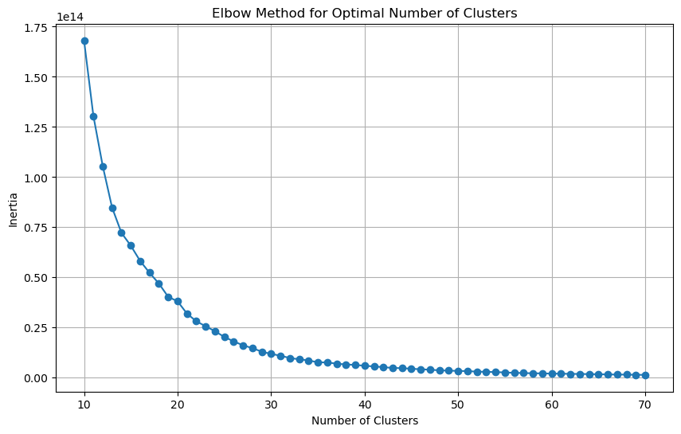

```python
# elbow method to find out the right number of clusters.

# Compute K-Means for each number of clusters specified in cluster_range
inertia = []
for n_clusters in cluster_range:
    kmeans = KMeans(n_clusters=n_clusters, random_state=0)
    kmeans.fit(user_vectors)
    inertia.append(kmeans.inertia_)

# Plot the Elbow curve
plt.figure(figsize=(10, 6))
plt.plot(cluster_range, inertia, marker='o')
plt.xlabel('Number of Clusters')
plt.ylabel('Inertia')
plt.title('Elbow Method for Optimal Number of Clusters')
plt.grid(True)
plt.show()
```

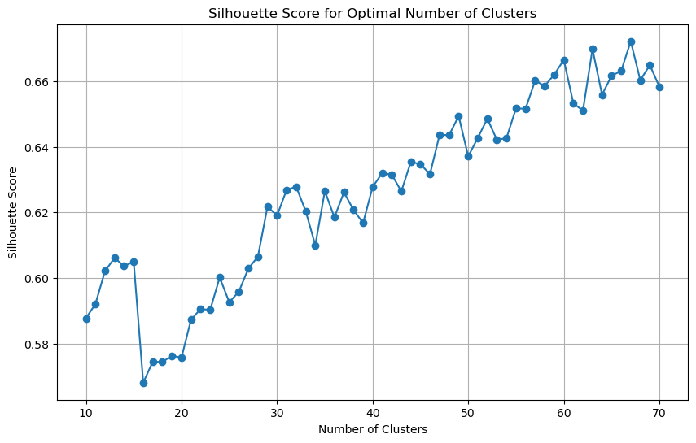

```python
# silhouette score as alternative method to look at potential number of clusters

silhouette_scores = []
for n_clusters in cluster_range:
    kmeans = KMeans(n_clusters=n_clusters, random_state=0)
    cluster_labels = kmeans.fit_predict(user_vectors)
    silhouette_avg = silhouette_score(user_vectors, cluster_labels)
    silhouette_scores.append(silhouette_avg)

# Plot the Silhouette scores
plt.figure(figsize=(10, 6))
plt.plot(cluster_range, silhouette_scores, marker='o')
plt.xlabel('Number of Clusters')
plt.ylabel('Silhouette Score')
plt.title('Silhouette Score for Optimal Number of Clusters')
plt.grid(True)
plt.show()
```

Running several versions of elbow and silhouette method with different cluster ranges (up to 70 clusters) leads to the initial decision to go forward with 25 clusters, as it seems to be a reasonable compromise of acceptable scores and a manageable number of clusters.

Trying out different numbers of clusters leads to the conclusion, that with up to 70 clusters, no good separation can be achieved.

Both 2D and 3D Visualization were applied to inspect the outcomes. No good outcomes were achieved in any visualization.

```python
# setting the number of clusters to be calculated, can be changed to experiement with different outcomes
optimal_n_clusters = 35

# Fit K-Means model with the chosen number of clusters
kmeans = KMeans(n_clusters=optimal_n_clusters, random_state=0)
user_vectors['cluster'] = kmeans.fit_predict(user_vectors)
```

```python
# Get cluster profiles
cluster_profiles = user_vectors.groupby('cluster').mean()
print(cluster_profiles.head())
```

```
           num_pages  ratings_count   biography   children    comics  \
cluster
0         729.698353   2.019763e+05    0.193862   0.036677  0.111527
1        2157.882883   2.867410e+06    4.331081   0.218468  0.000000
2        1756.782263   1.059470e+06    0.622730   0.550908  0.116407
3        2356.324266   2.103519e+06    2.000864   0.049223  0.033679
4        2008.033333   4.511307e+06    0.000000   3.966667  0.000000

            crime   fantasy   fiction   graphic   historical fiction  ...  \
cluster                                                               ...
0        1.014970  0.990269  2.440120  0.687874             0.193862  ...
1        0.067568  0.144144  0.425676  0.000000             4.331081  ...
2        1.129864  1.641537  3.739462  0.159209             0.622730  ...
3        0.076857  0.084629  4.319516  0.045337             2.000864  ...
4        0.000000  0.000000  3.966667  0.000000             0.000000  ...

          youngadult  children    comics   fantasy   fiction   mystery  \
cluster
0           1.301647  0.000000  0.576347  1.062874  0.049401  0.014970
1           0.385135  0.033784  0.000000  0.202703  4.457207  0.027027
2           2.336089  0.444066  0.042802  1.136835  0.416991  0.238327
3           2.424007  0.031088  0.011658  2.571244  0.174439  0.005181
4           3.966667  0.000000  0.000000  3.966667  0.044444  0.000000

         nonfiction    poetry   romance  youngadult
cluster
0          0.366766  0.000000  0.251497    0.441617
1          0.051802  0.076577  0.000000    0.033784
2          0.218547  0.003891  0.648833    1.013457
3          1.665371  0.000000  0.015544    0.019430
4          0.000000  0.000000  0.000000    0.000000

[5 rows x 27 columns]
```

Initially the viridis color palette was used, but this is very monotonic. A change to Paired helped the visualization in general, but not the outcome.

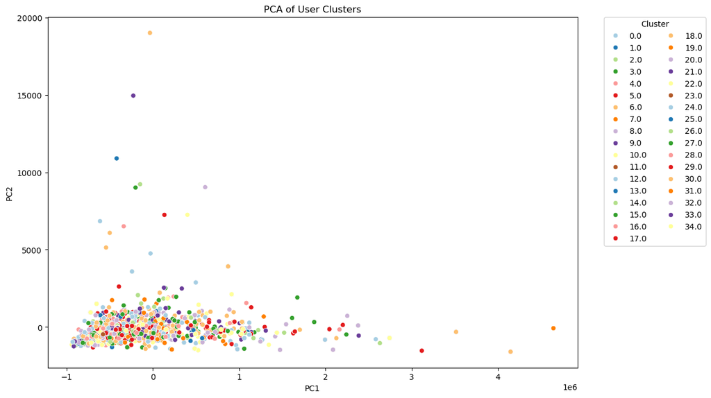

```python
# Reduce to 2D for visualization
pca = PCA(n_components=2)
reduced_data = pca.fit_transform(user_vectors.drop('cluster', axis=1))

# Create a DataFrame for plotting
df_pca = pd.DataFrame(reduced_data, columns=['PC1', 'PC2'])
df_pca['cluster'] = user_vectors['cluster']

# Plot the clusters
plt.figure(figsize=(12, 8))
sns.scatterplot(data=df_pca, x='PC1', y='PC2', hue='cluster', palette='Paired', legend='full')
plt.title('PCA of User Clusters')
# Adjust the legend to fit into the visual
plt.legend(title='Cluster', bbox_to_anchor=(1.05, 1), loc='upper left', borderaxespad=0, ncol=2)
plt.show()
```

```python
#Creating 3d visualization, to see if this leads to a better visualization
# # prepare data for it

# Perform PCA to reduce to 3D
pca = PCA(n_components=3)
reduced_data = pca.fit_transform(user_vectors.drop('cluster', axis=1))

# Create a DataFrame for plotting
df_pca = pd.DataFrame(reduced_data, columns=['PC1', 'PC2', 'PC3'])
df_pca['cluster'] = user_vectors['cluster']
```

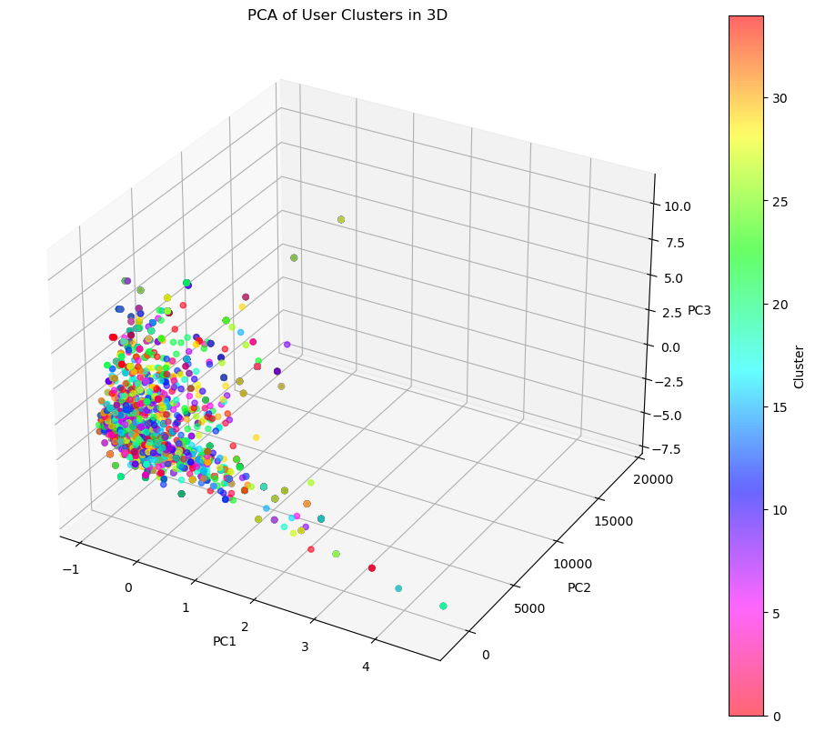

```python
#create 3D scatter plot, starting with Viridis again

# Create a 3D scatter plot
fig = plt.figure(figsize=(12, 10))
ax = fig.add_subplot(111, projection='3d')

# Scatter plot
scatter = ax.scatter(df_pca['PC1'], df_pca['PC2'], df_pca['PC3'],
                     c=df_pca['cluster'], cmap='hsv_r', alpha=0.6)

# Add color bar
cbar = plt.colorbar(scatter)
cbar.set_label('Cluster')

# Labels and title
ax.set_xlabel('PC1')
ax.set_ylabel('PC2')
ax.set_zlabel('PC3')
ax.set_title('PCA of User Clusters in 3D')

plt.show()
```

## Clustering with DBSCAN

As the approach using K-Means did not yield statisfying results, another approach was tried, using the DB Scan method. In general, the same steps as for the first clusterin appraoch were followed.

```python
# Following the same steps as for K-Means Clustering, steps are repeated as normalization in step 4 is used here
# Step 1: Create the user-item matrix combined with book metadata
user_item_with_metadata = merged_df.copy()

# Identify numeric columns (metadata columns plus genre dummies)
numeric_columns = ['num_pages', 'ratings_count'] + [col for col in genre_dummies.columns if pd.api.types.is_numeric_dtype(genre_dummies[col])]

# Step 2: Multiply each user's rating by the corresponding numeric metadata column
# Filter out non-numeric columns from `user_item_with_metadata`
numeric_metadata_columns = [col for col in numeric_columns if col in user_item_with_metadata.columns]

# Ensure 'Actual Rating' is numeric
user_item_with_metadata['Actual Rating'] = pd.to_numeric(user_item_with_metadata['Actual Rating'], errors='coerce')

# Apply multiplication only on numeric columns
for col in numeric_metadata_columns:
    if col in user_item_with_metadata.columns:
        user_item_with_metadata[col] = user_item_with_metadata['Actual Rating'] * user_item_with_metadata[col]

# Drop non-numeric columns before aggregation
user_item_with_metadata_numeric = user_item_with_metadata[numeric_metadata_columns + ['user_id_mapping']]

# Step 3: Aggregate the vectors for each user
user_vectors = user_item_with_metadata_numeric.groupby('user_id_mapping').mean()

# Step 4: Normalization
user_vectors_normalized = pd.DataFrame(
   normalize(user_vectors, norm='l2'),
   index=user_vectors.index,
   columns=user_vectors.columns
)

# Step 5: Review the final user vectors
print("Aggregated and Normalized User Vectors Head:")
print(user_vectors_normalized.head())
```

```
Aggregated and Normalized User Vectors Head:
                 num_pages  ratings_count   biography   children    comics  \
user_id_mapping
2                 0.001500       0.999999    0.000000   0.000000  0.000000
4                 0.001739       0.999998    0.000000   0.000007  0.000000
7                 0.000779       1.000000    0.000003   0.000000  0.000003
21                0.001113       0.999999    0.000000   0.000000  0.000000
23                0.002463       0.999997    0.000000   0.000000  0.000000

                    crime   fantasy   fiction   graphic   historical fiction  \
user_id_mapping
2                0.000000  0.000005  0.000005  0.000000             0.000000
4                0.000000  0.000000  0.000007  0.000000             0.000000
7                0.000000  0.000000  0.000003  0.000003             0.000003
21               0.000005  0.000005  0.000000  0.000000             0.000000
23               0.000000  0.000017  0.000017  0.000017             0.000000

                 ...   youngadult  children    comics   fantasy   fiction  \
user_id_mapping  ...
2                ...     0.000005       0.0  0.000000  0.000000  0.000000
4                ...     0.000007       0.0  0.000000  0.000007  0.000000
7                ...     0.000003       0.0  0.000000  0.000000  0.000000
21               ...     0.000000       0.0  0.000000  0.000000  0.000005
23               ...     0.000000       0.0  0.000017  0.000000  0.000000

                 mystery  nonfiction  poetry   romance  youngadult
user_id_mapping
2                    0.0    0.000000     0.0  0.000005         0.0
4                    0.0    0.000000     0.0  0.000000         0.0
7                    0.0    0.000003     0.0  0.000000         0.0
21                   0.0    0.000000     0.0  0.000000         0.0
23                   0.0    0.000000     0.0  0.000000         0.0

[5 rows x 27 columns]
```

```python
# Standardize the data (important for DBSCAN)
scaler = StandardScaler()
X_scaled = scaler.fit_transform(user_vectors_normalized)
```

```python
# Initialize DBSCAN with chosen parameters
dbscan = DBSCAN(eps=1, min_samples=5)

# Fit the model to the scaled data
dbscan.fit(X_scaled)

#  labels assigned to each data point
labels = dbscan.labels_
```

```python
# Number of clusters (excluding noise)
n_clusters = len(set(labels)) - (1 if -1 in labels else 0)

# Number of noise points
n_noise = list(labels).count(-1)

print(f'Estimated number of clusters: {n_clusters}')
print(f'Estimated number of noise points: {n_noise}')
```

```
Estimated number of clusters: 72
Estimated number of noise points: 891
```

```python
# Calculate silhouette score (ignoring noise)
silhouette = silhouette_score(X_scaled, labels) if len(set(labels)) > 1 else -1
print(f'Silhouette Score: {silhouette}')
```

```
Silhouette Score: 0.28371653379391715
```

```python
# #random search cv
# dbscan = DBSCAN()

# param_dist = {
#     'eps': np.linspace(1, 5, 5),  # setting the epsilon parameter
#     'min_samples': range(2, 20)        # setting min samples to form a cluster
# }


# def ari_scorer(estimator, X, y_true):
#     cluster_labels = estimator.fit_predict(X)
#     if len(set(cluster_labels)) > 1:  # Ensure there's more than one cluster
#         return adjusted_rand_score(y_true, cluster_labels)
#     else:
#         return -1  # Assign a low score if clustering is trivial

# # Example usage in RandomizedSearchCV
# ari = make_scorer(ari_scorer, needs_proba=False)



# # RandomizedSearchCV setup
# random_search = RandomizedSearchCV(
#     estimator=dbscan,
#     param_distributions=param_dist,
#     n_iter=100,                   # Number of parameter settings to sample
#     scoring=ari,           # Use the custom silhouette scoring function
#     cv=3,                         # Number of folds (not used, but required by RandomizedSearchCV)
#     verbose=1,
#     random_state=42,
#     n_jobs=-1
# )


# random_search.fit(X_scaled)

# # Best hyperparameters and corresponding score
# print("Best Hyperparameters:", random_search.best_params_)
# print("Best Silhouette Score:", random_search.best_score_)

'''
We are commenting this code out, as the output is quite large and did not provide usable insights.
'''
```

```
'\nWe are commenting this code out, as the output is quite large and did not provide usable insights.\n'
```

Plotting the result verifies that this is really not helpfull in moving forward.

```python
# Strip leading and trailing spaces from the column names
user_vectors.columns = user_vectors.columns.str.strip()

# Verify that the column names have been cleaned
print(user_vectors.columns)
```

```
Index(['num_pages', 'ratings_count', 'biography', 'children', 'comics',
       'crime', 'fantasy', 'fiction', 'graphic', 'historical fiction',
       'history', 'mystery', 'nonfiction', 'paranormal', 'poetry', 'romance',
       'thriller', 'youngadult', 'children', 'comics', 'fantasy', 'fiction',
       'mystery', 'nonfiction', 'poetry', 'romance', 'youngadult'],
      dtype='object')
```

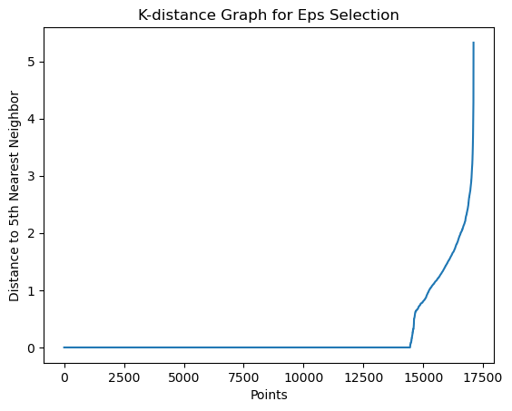

```python
# Assuming 'user_vectors' is your DataFrame with features
# Select only the relevant columns for clustering (e.g., drop 'cluster' or non-feature columns)
features = user_vectors[['num_pages', 'ratings_count', 'biography', 'children', 'comics',
                         'crime', 'fantasy', 'fiction', 'graphic', 'historical fiction',
                         'history', 'mystery', 'nonfiction', 'paranormal', 'poetry',
                         'romance', 'thriller', 'youngadult']]  # Example of selected columns

# Step 1: Normalize the data
scaler = StandardScaler()
X_scaled = scaler.fit_transform(features)

# Step 2: Define NearestNeighbors and compute distances
neighbors = NearestNeighbors(n_neighbors=5)  # Set n_neighbors to min_samples or another reasonable value
neighbors_fit = neighbors.fit(X_scaled)

# Step 3: Find the k-neighbors for each point
distances, indices = neighbors_fit.kneighbors(X_scaled)

# Step 4: Sort the distances for k-nearest neighbors and plot
distances = np.sort(distances[:, 4], axis=0)  # 4 corresponds to the 5th nearest neighbor (index 4 = n_neighbors - 1)
plt.plot(distances)
plt.title('K-distance Graph for Eps Selection')
plt.xlabel('Points')
plt.ylabel('Distance to 5th Nearest Neighbor')
plt.show()
```

```python
# Fit DB-Scan model
dbscan = DBSCAN(eps=0.1, min_samples=2)

user_vectors['cluster'] = dbscan.fit_predict(user_vectors)
```

```python
# Get cluster profiles
cluster_profiles = user_vectors.groupby('cluster').mean()
print(cluster_profiles.head())
```

```
           num_pages  ratings_count  biography  children    comics     crime  \
cluster
-1       1494.978948   9.550478e+05   0.886546  0.702839  0.285074  1.117332
 0       1240.000000   8.265840e+05   0.000000  0.000000  0.000000  0.000000
 1        720.000000   4.140090e+05   0.000000  3.000000  0.000000  0.000000
 2       1164.000000   1.494384e+06   4.000000  0.000000  4.000000  0.000000
 3        448.000000   4.023920e+05   0.000000  0.000000  0.000000  2.000000

          fantasy   fiction   graphic  historical fiction  ...  youngadult  \
cluster                                                    ...
-1       1.114097  3.042178  0.513439            0.886546  ...    2.058673
 0       4.000000  4.000000  0.000000            0.000000  ...    4.000000
 1       0.000000  3.000000  0.000000            0.000000  ...    3.000000
 2       0.000000  4.000000  4.000000            4.000000  ...    4.000000
 3       2.000000  0.000000  0.000000            0.000000  ...    0.000000

         children    comics   fantasy   fiction   mystery  nonfiction  \
cluster
-1       0.098984  0.228365  1.341245  0.666771  0.073136    0.455267
 0       0.000000  0.000000  0.000000  0.000000  0.000000    0.000000
 1       0.000000  0.000000  3.000000  0.000000  0.000000    0.000000
 2       0.000000  0.000000  0.000000  0.000000  0.000000    4.000000
 3       0.000000  0.000000  0.000000  2.000000  0.000000    0.000000

          poetry   romance  youngadult
cluster
-1       0.02906  0.237636    0.660511
 0       0.00000  4.000000    0.000000
 1       0.00000  0.000000    0.000000
 2       0.00000  0.000000    0.000000
 3       0.00000  0.000000    0.000000

[5 rows x 27 columns]
```

Plotting the clusters that the DBScan Method is creating. The result is not nice, and too many clusters are identified.

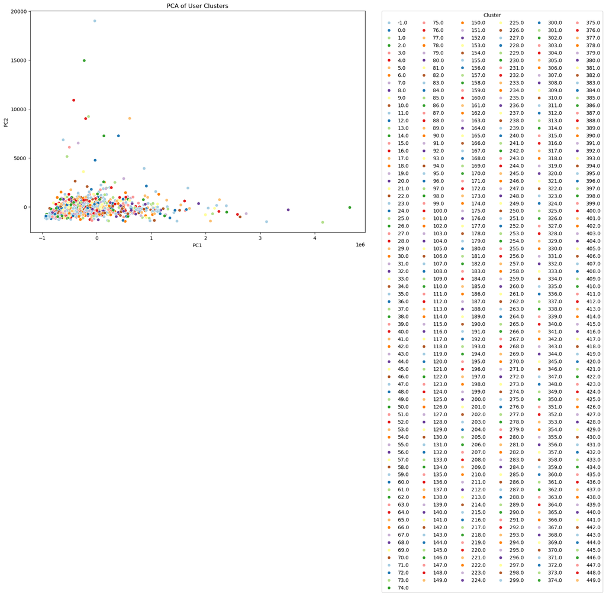

```python
#initially it was viridis color palette, but that was very monotonic, changed it to Paired, still not very helpful

# Reduce to 2D for visualization
pca = PCA(n_components=2)
reduced_data = pca.fit_transform(user_vectors.drop('cluster', axis=1))

# Create a DataFrame for plotting
df_pca = pd.DataFrame(reduced_data, columns=['PC1', 'PC2'])
df_pca['cluster'] = user_vectors['cluster']

# Plot the clusters
plt.figure(figsize=(12, 8))
sns.scatterplot(data=df_pca, x='PC1', y='PC2', hue='cluster', palette='Paired', legend='full')
plt.legend(title='Cluster', bbox_to_anchor=(1.05, 1), loc='upper left', borderaxespad=0, ncol=6)
plt.title('PCA of User Clusters')
plt.show()
```

Experimenting with 3D visualization to see if this helps to evaluate the clustering. It verifies that no good clusters could be created, even with a very high number of clusters.

```python
# 3d visualization

# Perform PCA to reduce to 3D
pca = PCA(n_components=3)
reduced_data = pca.fit_transform(user_vectors.drop('cluster', axis=1))

# Create a DataFrame for plotting
df_pca = pd.DataFrame(reduced_data, columns=['PC1', 'PC2', 'PC3'])
df_pca['cluster'] = user_vectors['cluster']
```

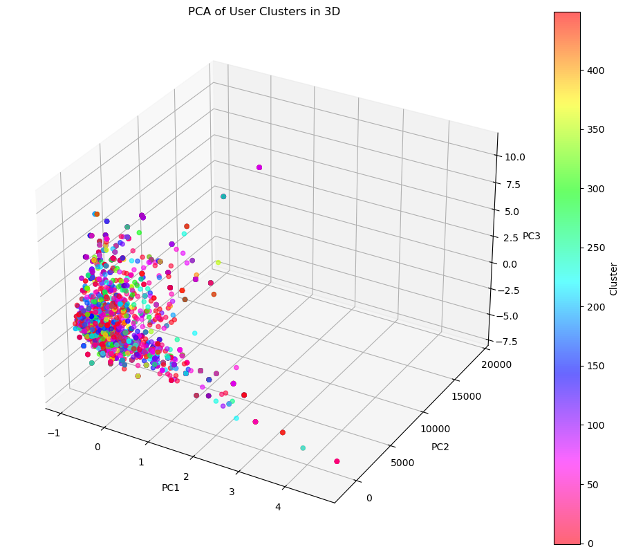

```python
#create 3D scatter plot, starting with Viridis again

# Create a 3D scatter plot
fig = plt.figure(figsize=(12, 10))
ax = fig.add_subplot(111, projection='3d')

# Scatter plot
scatter = ax.scatter(df_pca['PC1'], df_pca['PC2'], df_pca['PC3'],
                     c=df_pca['cluster'], cmap='hsv_r', alpha=0.6)

# Add color bar
cbar = plt.colorbar(scatter)
cbar.set_label('Cluster')

# Labels and title
ax.set_xlabel('PC1')
ax.set_ylabel('PC2')
ax.set_zlabel('PC3')
ax.set_title('PCA of User Clusters in 3D')

plt.show()
```

### Insights/ Findings

We started with the hypthesis, that creating clusters of users would be beneficial as input for the following work to predict how users or user within a certain cluster would rate a certain book. Trying out different ways to cluster the user data and evaluating the results shows, that no good way could be found to cluster the data to use it going forward. Therefore the decision was made to not use clusters for prediction, but use the data about the individual users and experiment with prediction based on the users directly.

## Topic Modeling of book blurb

```python
#  helper functions for preprocessing
def remove_punctuation(x):
    cleanedtext=re.sub('[^A-Za-z0-9]+', ' ', x)
    return cleanedtext

def tokenize_column(column): # this function tests gensim tokenize function used in vectorizer, not used
    l=[]
    for x in range(len(column)):
        l.append(list(tokenize(column.iloc[x])))
    return l

fulldatadf['description']=fulldatadf.description.transform(remove_punctuation)
# fulldatadf['description_list']=tokenize_column(fulldatadf.description)
# fulldatadf['description_list']
```

```python
# xtrain,xtest=train_test_split(fulldatadf['description'],test_size=0.1,random_state=randomstate,shuffle=True)
```

## group books via blurb content

### ideas:

- vectorize via topics from topic modeling
- tfidf -> lda
  - evaluate via topic coherence

```python
def topiccoherencescorer(pipe,x):
    n_top_words = 10 #higher value for higher coherence, i.e. more word to make connections for coherence
    topics=pipe.named_steps['lda'].components_
    texts=[[word for word in doc.split()] for doc in x]

    dictionary=corpora.Dictionary(texts)
    corpus=[dictionary.doc2bow(text) for text in texts]
    feature_names = [dictionary[i] for i in range(len(dictionary))]
    top_words = []
    for topic in topics:
        top_words.append([feature_names[i] for i in topic.argsort()[:-n_top_words - 1:-1]])
    cm = CoherenceModel(topics=top_words, texts=texts, dictionary=dictionary, coherence='c_v') #other coherence metrics possible, sticking with c_v
    return cm.get_coherence()
```

### optima study for tfidf+lda

```python
retrain_studydescription_tfidflda=True
studyname='description_tfidflda_study'
thismodelpath=models_path.joinpath(f'{studyname}')
try:
    thismodelpath.mkdir(exist_ok=False)
except FileExistsError:
    print('Directory already exists')
if retrain_studydescription_tfidflda:
    xtrain,xtest=train_test_split(fulldatadf['description'],test_size=0.1,random_state=randomstate,shuffle=True)
    xtrain,xtest=xtrain.reset_index(drop=True),xtest.reset_index(drop=True) #kf.split() needs reset index; if drop=False, index turned into new column


    def inst_tfidf(trial:Trial)->TfidfVectorizer:
        params={
            'norm':trial.suggest_categorical('norm',['l1','l2', None]),
            'smooth_idf':trial.suggest_categorical('smooth_idf',[True,False]),
            'sublinear_tf':trial.suggest_categorical('sublinear_tf',[True,False]),
            'stop_words':trial.suggest_categorical('stop_words',['english',list(STOPWORDS)]),
            'tokenizer':tokenize,
            # 'max_df':trial.suggest_float('max_df',0,1),
            # 'min_df':trial.suggest_float('min_df',0,1),
            # 'max_features':trial.suggest_categorical('max_features',[None,100,50,25,10]) #can't use int, because of None, PS: no max features, filters out too many words
            }
        return TfidfVectorizer(**params)
    def inst_lda(trial:Trial)->LatentDirichletAllocation:
        params={
            'n_components':trial.suggest_int('n_components',3,20),
            # 'learning_method':trial.suggest_categorical('learning_method',['batch','online']),
            # 'learning_decay':trial.suggest_float('learning_decay',0.5,0.9),
            # 'learning_offset':trial.suggest_float('learning_offset',2,20),
            # 'max_iter':trial.suggest_int('max_iter',2,20),
            # 'batch_size':trial.suggest_int('batch_size',5,20),
            # 'max_doc_update_iter':trial.suggest_int('max_doc_update_iter',0,10),
            'n_jobs':-1,
            'random_state':randomstate
        }
        return LatentDirichletAllocation(**params)
    def inst_pipeTFLDA(trial:Trial)->Pipeline:
        pipeline=Pipeline([
            ('vectorizer',inst_tfidf(trial)),
            ('lda',inst_lda(trial))
        ])
        return pipeline

    def objective(trial:Trial,xtrain:pd.DataFrame)->float:
        kf = KFold(n_splits=5, shuffle=True, random_state=randomstate)
        model=inst_pipeTFLDA(trial)
        scores=[]
        for x in kf.split(xtrain):
            subxtrain=xtrain.loc[x[0]]

            pipe=model.fit(subxtrain)
            score=topiccoherencescorer(pipe, subxtrain) #prev no cv, as scorer not compatible
            scores.append(score)

        # scores = cross_val_score(model, x, cv=kf) #using default scorer --> approx log-likelohood
        # return np.min([np.mean(scores), np.median(scores)])
        return np.mean(scores)
    storage=thismodelpath.joinpath("description_tfidflda_study.db")
    if storage.exists():
        storage.unlink()
    else:
        print("No sqlite db found")

    study=create_study(study_name=studyname,direction='maximize',storage=f'sqlite:///{storage.as_posix()}',load_if_exists=False) #TPESampler used as default, no pruning
    study.optimize(lambda trial: objective(trial,xtrain),n_trials=25,n_jobs=-1,show_progress_bar=True)
    joblib.dump(study,thismodelpath.joinpath(f'study_{study.study_name}.pkl').as_posix())

    model = inst_pipeTFLDA(study.best_trial)
    fitpipe=model.fit(fulldatadf.description)
    joblib.dump(fitpipe,thismodelpath.joinpath(f'fitpipelinedefault.pkl').as_posix())

else:
    fitpipe=joblib.load(thismodelpath.joinpath(f'fitpipelinedefault.pkl').as_posix())
```

```
Directory already exists
```

```
[I 2024-09-08 15:43:01,351] A new study created in RDB with name: description_tfidflda_study
```

```
[I 2024-09-08 15:46:49,532] Trial 10 finished with value: 0.6241511942136642 and parameters: {'norm': 'l1', 'smooth_idf': False, 'sublinear_tf': True, 'stop_words': 'english', 'n_components': 3}. Best is trial 10 with value: 0.6241511942136642.
```

```
[I 2024-09-08 15:46:50,847] Trial 3 finished with value: 0.6385176617787506 and parameters: {'norm': 'l1', 'smooth_idf': True, 'sublinear_tf': True, 'stop_words': 'english', 'n_components': 9}. Best is trial 3 with value: 0.6385176617787506.
[I 2024-09-08 15:46:50,938] Trial 15 finished with value: 0.6293798566278095 and parameters: {'norm': 'l1', 'smooth_idf': False, 'sublinear_tf': True, 'stop_words': 'english', 'n_components': 7}. Best is trial 3 with value: 0.6385176617787506.
```

```
[I 2024-09-08 15:46:51,861] Trial 7 finished with value: 0.6411183319539064 and parameters: {'norm': 'l1', 'smooth_idf': True, 'sublinear_tf': False, 'stop_words': ['my', 'bill', 'him', 'whose', 'keep', 'hereafter', 'we', 'doesn', 'as', 'regarding', 'further', 'somehow', 'throughout', 'himself', 'so…
```

```
[I 2024-09-08 15:46:54,837] Trial 9 finished with value: 0.6260434982099576 and parameters: {'norm': 'l1', 'smooth_idf': False, 'sublinear_tf': True, 'stop_words': 'english', 'n_components': 8}. Best is trial 7 with value: 0.6411183319539064.
[I 2024-09-08 15:46:54,933] Trial 4 finished with value: 0.6212449657268124 and parameters: {'norm': 'l1', 'smooth_idf': True, 'sublinear_tf': True, 'stop_words': 'english', 'n_components': 17}. Best is trial 7 with value: 0.6411183319539064.
```

```
[I 2024-09-08 15:46:55,053] Trial 1 finished with value: 0.6309147168070753 and parameters: {'norm': 'l2', 'smooth_idf': False, 'sublinear_tf': False, 'stop_words': ['my', 'bill', 'him', 'whose', 'keep', 'hereafter', 'we', 'doesn', 'as', 'regarding', 'further', 'somehow', 'throughout', 'himself', 's…
[I 2024-09-08 15:46:55,146] Trial 5 finished with value: 0.6380689473015876 and parameters: {'norm': 'l2', 'smooth_idf': False, 'sublinear_tf': False, 'stop_words': 'english', 'n_components': 7}. Best is trial 7 with value: 0.6411183319539064.
```

```
[I 2024-09-08 15:46:55,193] Trial 8 finished with value: 0.631707610623633 and parameters: {'norm': None, 'smooth_idf': False, 'sublinear_tf': False, 'stop_words': 'english', 'n_components': 12}. Best is trial 7 with value: 0.6411183319539064.
```

```
[I 2024-09-08 15:46:55,467] Trial 13 finished with value: 0.6180533711683664 and parameters: {'norm': None, 'smooth_idf': True, 'sublinear_tf': True, 'stop_words': ['my', 'bill', 'him', 'whose', 'keep', 'hereafter', 'we', 'doesn', 'as', 'regarding', 'further', 'somehow', 'throughout', 'himself', 'so…
[I 2024-09-08 15:46:55,475] Trial 0 finished with value: 0.6186761858703398 and parameters: {'norm': 'l1', 'smooth_idf': False, 'sublinear_tf': False, 'stop_words': 'english', 'n_components': 13}. Best is trial 7 with value: 0.6411183319539064.
[I 2024-09-08 15:46:55,477] Trial 14 finished with value: 0.6372701220799267 and parameters: {'norm': 'l2', 'smooth_idf': False, 'sublinear_tf': False, 'stop_words': 'english', 'n_components': 20}. Best is trial 7 with value: 0.6411183319539064.
[I 2024-09-08 15:46:55,481] Trial 12 finished with value: 0.6280503141198077 and parameters: {'norm': 'l2', 'smooth_idf': False, 'sublinear_tf': False, 'stop_words': 'english', 'n_components': 15}. Best is trial 7 with value: 0.6411183319539064.
[I 2024-09-08 15:46:55,578] Trial 2 finished with value: 0.6216604085433245 and parameters: {'norm': None, 'smooth_idf': False, 'sublinear_tf': True, 'stop_words': ['my', 'bill', 'him', 'whose', 'keep', 'hereafter', 'we', 'doesn', 'as', 'regarding', 'further', 'somehow', 'throughout', 'himself', 'so…
```

```
[I 2024-09-08 15:46:55,643] Trial 11 finished with value: 0.6201859977865471 and parameters: {'norm': None, 'smooth_idf': False, 'sublinear_tf': False, 'stop_words': ['my', 'bill', 'him', 'whose', 'keep', 'hereafter', 'we', 'doesn', 'as', 'regarding', 'further', 'somehow', 'throughout', 'himself', '…
[I 2024-09-08 15:46:55,645] Trial 6 finished with value: 0.6208578998267893 and parameters: {'norm': None, 'smooth_idf': False, 'sublinear_tf': True, 'stop_words': ['my', 'bill', 'him', 'whose', 'keep', 'hereafter', 'we', 'doesn', 'as', 'regarding', 'further', 'somehow', 'throughout', 'himself', 'so…
```

```
[I 2024-09-08 15:48:46,598] Trial 16 finished with value: 0.6397884527312674 and parameters: {'norm': 'l2', 'smooth_idf': False, 'sublinear_tf': False, 'stop_words': 'english', 'n_components': 11}. Best is trial 7 with value: 0.6411183319539064.
```

```
[I 2024-09-08 15:48:49,898] Trial 17 finished with value: 0.6497281726212079 and parameters: {'norm': 'l1', 'smooth_idf': True, 'sublinear_tf': True, 'stop_words': ['my', 'bill', 'him', 'whose', 'keep', 'hereafter', 'we', 'doesn', 'as', 'regarding', 'further', 'somehow', 'throughout', 'himself', 'so…
```

```
[I 2024-09-08 15:48:51,439] Trial 19 finished with value: 0.6241733761934759 and parameters: {'norm': 'l2', 'smooth_idf': True, 'sublinear_tf': False, 'stop_words': 'english', 'n_components': 15}. Best is trial 17 with value: 0.6497281726212079.
```

```
[I 2024-09-08 15:48:52,110] Trial 18 finished with value: 0.6497281726212079 and parameters: {'norm': 'l1', 'smooth_idf': True, 'sublinear_tf': True, 'stop_words': ['my', 'bill', 'him', 'whose', 'keep', 'hereafter', 'we', 'doesn', 'as', 'regarding', 'further', 'somehow', 'throughout', 'himself', 'so…
```

```
[I 2024-09-08 15:48:54,893] Trial 21 finished with value: 0.6221220642480134 and parameters: {'norm': 'l1', 'smooth_idf': True, 'sublinear_tf': False, 'stop_words': ['my', 'bill', 'him', 'whose', 'keep', 'hereafter', 'we', 'doesn', 'as', 'regarding', 'further', 'somehow', 'throughout', 'himself', 's…
```

```
[I 2024-09-08 15:48:55,318] Trial 24 finished with value: 0.6497281726212079 and parameters: {'norm': 'l1', 'smooth_idf': True, 'sublinear_tf': True, 'stop_words': ['my', 'bill', 'him', 'whose', 'keep', 'hereafter', 'we', 'doesn', 'as', 'regarding', 'further', 'somehow', 'throughout', 'himself', 'so…
[I 2024-09-08 15:48:55,365] Trial 23 finished with value: 0.6290793156320923 and parameters: {'norm': 'l1', 'smooth_idf': True, 'sublinear_tf': True, 'stop_words': ['my', 'bill', 'him', 'whose', 'keep', 'hereafter', 'we', 'doesn', 'as', 'regarding', 'further', 'somehow', 'throughout', 'himself', 'so…
[I 2024-09-08 15:48:55,371] Trial 20 finished with value: 0.6221220642480134 and parameters: {'norm': 'l1', 'smooth_idf': True, 'sublinear_tf': False, 'stop_words': ['my', 'bill', 'him', 'whose', 'keep', 'hereafter', 'we', 'doesn', 'as', 'regarding', 'further', 'somehow', 'throughout', 'himself', 's…
[I 2024-09-08 15:48:55,426] Trial 22 finished with value: 0.6290793156320923 and parameters: {'norm': 'l1', 'smooth_idf': True, 'sublinear_tf': True, 'stop_words': ['my', 'bill', 'him', 'whose', 'keep', 'hereafter', 'we', 'doesn', 'as', 'regarding', 'further', 'somehow', 'throughout', 'himself', 'so…
```

```python
no_top_words=10
topics=fitpipe.named_steps['lda'].components_
for topic in topics:
    print(" ".join([fitpipe.named_steps['vectorizer'].get_feature_names_out()[i] for i in topic.argsort()[:-no_top_words - 1:-1]]))
```

```
s life t way horn new time long law love
s story world new tale life love come time age
story son harry father s unexpected t youngest wanted past
```

### optima study for cv+lda

```python
retrain_studydescription_countveclda=True

studyname='description_countlda_study'
thismodelpath=models_path.joinpath(f'{studyname}')
try:
    thismodelpath.mkdir(exist_ok=False)
except FileExistsError:
    print('Directory already exists')
if retrain_studydescription_countveclda:
    xtrain,xtest=train_test_split(fulldatadf['description'],test_size=0.1,random_state=randomstate,shuffle=True)
    xtrain,xtest=xtrain.reset_index(drop=True),xtest.reset_index(drop=True) #kf.split() needs reset index; if drop=False, index turned into new column

    def inst_countvec(trial:Trial)->CountVectorizer:
        params={
            'stop_words':trial.suggest_categorical('stop_words',['english',list(STOPWORDS)]),
            'tokenizer':tokenize,
            # 'max_df':trial.suggest_float('max_df',0,1),
            # 'min_df':trial.suggest_float('min_df',0,1),
            # 'max_features':trial.suggest_categorical('max_features',[None,100,50,25,10]) #can't use int, because of None; do not set! will filter too many words
            }
        return CountVectorizer(**params)
    def inst_lda(trial:Trial)->LatentDirichletAllocation:
        params={
            'n_components':trial.suggest_int('n_components',3,20),
            # 'learning_method':trial.suggest_categorical('learning_method',['batch','online']),
            # 'learning_decay':trial.suggest_float('learning_decay',0.5,0.9),
            # 'learning_offset':trial.suggest_float('learning_offset',2,20),
            # 'max_iter':trial.suggest_int('max_iter',2,20),
            # 'batch_size':trial.suggest_int('batch_size',5,20),
            # 'max_doc_update_iter':trial.suggest_int('max_doc_update_iter',0,10),
            'n_jobs':-1,
            'random_state':randomstate
        }
        return LatentDirichletAllocation(**params)
    def inst_pipeTFLDA(trial:Trial)->Pipeline:
        pipeline=Pipeline([
            ('vectorizer',inst_countvec(trial)),
            ('lda',inst_lda(trial))
        ])
        return pipeline

    def objective(trial:Trial,x:pd.DataFrame)->float:
        kf = KFold(n_splits=5, shuffle=True, random_state=randomstate)
        model=inst_pipeTFLDA(trial)
        scores=[]
        for x in kf.split(xtrain):
            subxtrain=xtrain.loc[x[0]]

            pipe=model.fit(subxtrain)
            score=topiccoherencescorer(pipe,subxtrain) #no cv, as scorer not compatible
            scores.append(score)

            # scores = cross_val_score(model, x, cv=kf) #using default scorer --> approx log-likelohood
        # return np.min([np.mean(scores), np.median(scores)])
        return np.mean(scores)

    storage=thismodelpath.joinpath("description_countveclda_studydefault.db")
    if storage.exists():
        storage.unlink()
    else:
        print("No sqlite db found")

    study2=create_study(study_name=studyname,direction='maximize',storage=f'sqlite:///{storage.as_posix()}',load_if_exists=False) #TPESampler used as default, no pruning
    study2.optimize(lambda trial: objective(trial,xtrain),n_trials=25,n_jobs=-1,show_progress_bar=True)
    joblib.dump(study,thismodelpath.joinpath(f'study_{study.study_name}.pkl').as_posix())

    model = inst_pipeTFLDA(study.best_trial)
    fitpipe=model.fit(fulldatadf.description)
    joblib.dump(fitpipe,thismodelpath.joinpath(f'fittedpipelinedefault2.pkl').as_posix())
else:
    fitpipe=joblib.load(thismodelpath.joinpath(f'fittedpipelinedefault2.pkl').as_posix())
```

```
Directory already exists
```

```
[I 2024-09-08 15:48:56,204] A new study created in RDB with name: description_countlda_study
```

```
[I 2024-09-08 15:51:58,378] Trial 3 finished with value: 0.6376348382855158 and parameters: {'stop_words': 'english', 'n_components': 6}. Best is trial 3 with value: 0.6376348382855158.
```

```
[I 2024-09-08 15:52:00,931] Trial 11 finished with value: 0.6336377555448636 and parameters: {'stop_words': 'english', 'n_components': 4}. Best is trial 3 with value: 0.6376348382855158.
[I 2024-09-08 15:52:01,017] Trial 9 finished with value: 0.6300417038535931 and parameters: {'stop_words': ['my', 'bill', 'him', 'whose', 'keep', 'hereafter', 'we', 'doesn', 'as', 'regarding', 'further', 'somehow', 'throughout', 'himself', 'somewhere', 'hers', 'during', 'co', 'whither', 'because', '…
```

```
[I 2024-09-08 15:52:12,479] Trial 8 finished with value: 0.6325490289277648 and parameters: {'stop_words': ['my', 'bill', 'him', 'whose', 'keep', 'hereafter', 'we', 'doesn', 'as', 'regarding', 'further', 'somehow', 'throughout', 'himself', 'somewhere', 'hers', 'during', 'co', 'whither', 'because', '…
```

```
[I 2024-09-08 15:52:40,312] Trial 2 finished with value: 0.6276068090115572 and parameters: {'stop_words': 'english', 'n_components': 13}. Best is trial 3 with value: 0.6376348382855158.
```

```
[I 2024-09-08 15:52:40,823] Trial 14 finished with value: 0.6530389006334407 and parameters: {'stop_words': 'english', 'n_components': 3}. Best is trial 14 with value: 0.6530389006334407.
```

```
[I 2024-09-08 15:52:41,351] Trial 4 finished with value: 0.6301439060530812 and parameters: {'stop_words': ['my', 'bill', 'him', 'whose', 'keep', 'hereafter', 'we', 'doesn', 'as', 'regarding', 'further', 'somehow', 'throughout', 'himself', 'somewhere', 'hers', 'during', 'co', 'whither', 'because', '…
```

```
[I 2024-09-08 15:52:45,005] Trial 10 finished with value: 0.6325490289277648 and parameters: {'stop_words': ['my', 'bill', 'him', 'whose', 'keep', 'hereafter', 'we', 'doesn', 'as', 'regarding', 'further', 'somehow', 'throughout', 'himself', 'somewhere', 'hers', 'during', 'co', 'whither', 'because', …
```

```
[I 2024-09-08 15:52:45,552] Trial 12 finished with value: 0.6331332192675154 and parameters: {'stop_words': ['my', 'bill', 'him', 'whose', 'keep', 'hereafter', 'we', 'doesn', 'as', 'regarding', 'further', 'somehow', 'throughout', 'himself', 'somewhere', 'hers', 'during', 'co', 'whither', 'because', …
[I 2024-09-08 15:52:45,564] Trial 7 finished with value: 0.6286677394681384 and parameters: {'stop_words': 'english', 'n_components': 15}. Best is trial 14 with value: 0.6530389006334407.
[I 2024-09-08 15:52:45,665] Trial 1 finished with value: 0.6397787688139063 and parameters: {'stop_words': 'english', 'n_components': 5}. Best is trial 14 with value: 0.6530389006334407.
```

```
[I 2024-09-08 15:52:46,015] Trial 5 finished with value: 0.6317944601302492 and parameters: {'stop_words': 'english', 'n_components': 17}. Best is trial 14 with value: 0.6530389006334407.
[I 2024-09-08 15:52:46,026] Trial 13 finished with value: 0.6300417038535931 and parameters: {'stop_words': ['my', 'bill', 'him', 'whose', 'keep', 'hereafter', 'we', 'doesn', 'as', 'regarding', 'further', 'somehow', 'throughout', 'himself', 'somewhere', 'hers', 'during', 'co', 'whither', 'because', …
```

```
[I 2024-09-08 15:52:46,208] Trial 15 finished with value: 0.6341456332127604 and parameters: {'stop_words': 'english', 'n_components': 19}. Best is trial 14 with value: 0.6530389006334407.
[I 2024-09-08 15:52:46,240] Trial 6 finished with value: 0.6321756997589514 and parameters: {'stop_words': 'english', 'n_components': 16}. Best is trial 14 with value: 0.6530389006334407.
[I 2024-09-08 15:52:46,248] Trial 0 finished with value: 0.6300417038535931 and parameters: {'stop_words': ['my', 'bill', 'him', 'whose', 'keep', 'hereafter', 'we', 'doesn', 'as', 'regarding', 'further', 'somehow', 'throughout', 'himself', 'somewhere', 'hers', 'during', 'co', 'whither', 'because', '…
```

```
[I 2024-09-08 15:54:29,209] Trial 17 finished with value: 0.6371556698621996 and parameters: {'stop_words': ['my', 'bill', 'him', 'whose', 'keep', 'hereafter', 'we', 'doesn', 'as', 'regarding', 'further', 'somehow', 'throughout', 'himself', 'somewhere', 'hers', 'during', 'co', 'whither', 'because', …
[I 2024-09-08 15:54:29,228] Trial 16 finished with value: 0.639662801021175 and parameters: {'stop_words': 'english', 'n_components': 10}. Best is trial 14 with value: 0.6530389006334407.
[I 2024-09-08 15:54:29,243] Trial 19 finished with value: 0.6268309098521658 and parameters: {'stop_words': ['my', 'bill', 'him', 'whose', 'keep', 'hereafter', 'we', 'doesn', 'as', 'regarding', 'further', 'somehow', 'throughout', 'himself', 'somewhere', 'hers', 'during', 'co', 'whither', 'because', …
[I 2024-09-08 15:54:29,247] Trial 18 finished with value: 0.6276068090115572 and parameters: {'stop_words': 'english', 'n_components': 13}. Best is trial 14 with value: 0.6530389006334407.
```

```
[I 2024-09-08 15:54:47,840] Trial 20 finished with value: 0.6376348382855158 and parameters: {'stop_words': 'english', 'n_components': 6}. Best is trial 14 with value: 0.6530389006334407.
[I 2024-09-08 15:54:47,981] Trial 21 finished with value: 0.6530389006334407 and parameters: {'stop_words': 'english', 'n_components': 3}. Best is trial 14 with value: 0.6530389006334407.
[I 2024-09-08 15:54:48,012] Trial 24 finished with value: 0.6530389006334407 and parameters: {'stop_words': 'english', 'n_components': 3}. Best is trial 14 with value: 0.6530389006334407.
[I 2024-09-08 15:54:48,045] Trial 23 finished with value: 0.6530389006334407 and parameters: {'stop_words': 'english', 'n_components': 3}. Best is trial 14 with value: 0.6530389006334407.
[I 2024-09-08 15:54:48,075] Trial 22 finished with value: 0.6530389006334407 and parameters: {'stop_words': 'english', 'n_components': 3}. Best is trial 14 with value: 0.6530389006334407.
```

```python
no_top_words=10
topics=fitpipe.named_steps['lda'].components_
for topic in topics:
    print(" ".join([fitpipe.named_steps['vectorizer'].get_feature_names_out()[i] for i in topic.argsort()[:-no_top_words - 1:-1]]))
```

```
s t life way new time summer long save heart
s world love life new old women year story family
s eragon new story world life t author harry dragon
```

## lda with gridsearchcv and nmf as alternative

```python
# optimizing all hyperparameters makes script run endlessly, does not converge
# no max features for vectorizers
# nmf has no scorer, no further tries, as to focus on lda
retrain_tfidflda=True
retrain_cvlda=True

cv=CountVectorizer(tokenizer=tokenize)
tfidf=TfidfVectorizer(tokenizer=tokenize)
lda=LatentDirichletAllocation(n_jobs=-1,random_state=randomstate)
nmf=NMF(random_state=randomstate)
paramgrida={'vectorizer__stop_words':['english',list(STOPWORDS)],
            # 'vectorizer__max_features':[None,100,50],
            'lda__n_components':[3,5],
            # 'lda__learning_method':['batch','online'],
            # 'lda__learning_decay':[0.5,0.9,0.7],
            # 'lda__learning_offset':[2,10],
            # 'lda__max_iter':[2,10],
            # 'lda__batch_size':[10,50],
            # 'lda__max_doc_update_iter':[1,5]
            }
pipelinea=Pipeline([('vectorizer', cv),('lda',lda)])
paramgridb={'vectorizer__norm':['l1','l2', None],
            'vectorizer__smooth_idf':[True,False],
            'vectorizer__sublinear_tf':[True,False],
            'vectorizer__stop_words':['english',list(STOPWORDS)],
            # 'vectorizer__max_features':[None,100,50],
            'lda__n_components':[3,5],
            # 'lda__learning_method':['batch','online'],
            # 'lda__learning_decay':[0.5,0.9,0.7],
            # 'lda__learning_offset':[2,10],
            # 'lda__max_iter':[2,10],
            # 'lda__batch_size':[10,50],
            # 'lda__max_doc_update_iter':[1,5]
            }
pipelineb=Pipeline([('vectorizer', tfidf),('lda',lda)])
#nmf has no scorer, can't be optimized unless specified
# paramgridc={'nmf__n_components':['auto',None,5,10,25,50,100],
#             'nmf__init':['random', 'nndsvd', 'nndsvda', 'nndsvdar'],
#             # 'nmf__solver':['cd','mu'],
#             # 'nmf__beta_loss':['frobenius', 'kullback-leibler', 'itakura-saito'],
#             # 'nmf__tol':[0.001,0.01,0.003,0.03],
#             # 'nmf__max_iter':[20,50,100,200],
#             # 'nmf__alpha_W':[0.0,0.5,1],
#             # 'nmf__alpha_H':[0.0,0.5,1],
#             # 'nmf__l1_ratio':[0.0,0.25,0.5],
#             # 'nmf__shuffle':[True,False],
#             'vectorizer__stop_words':['english',list(STOPWORDS)],
#             'vectorizer__max_features':[None,100,50,25,10]
#             }
# pipelinec=Pipeline([('vectorizer', cv),('nmf',nmf)])
# paramgridd={'nmf__n_components':['auto',None,5,10,25,50,100],
#             'nmf__init':['random', 'nndsvd', 'nndsvda', 'nndsvdar'],
#             # 'nmf__solver':['cd','mu'],
#             # 'nmf__beta_loss':['frobenius', 'kullback-leibler', 'itakura-saito'],
#             # 'nmf__tol':[0.001,0.01,0.003,0.03],
#             # 'nmf__max_iter':[20,50,100,200],
#             # 'nmf__alpha_W':[0.0,0.5,1],
#             # 'nmf__alpha_H':[0.0,0.5,1],
#             # 'nmf__l1_ratio':[0.0,0.25,0.5],
#             # 'nmf__shuffle':[True,False],
#             'vectorizer__norm':['l1','l2', None],
#             'vectorizer__smooth_idf':[True,False],
#             'vectorizer__sublinear_tf':[True,False],
#             'vectorizer__stop_words':['english',list(STOPWORDS)],
#             'vectorizer__max_features':[None,100,50,25,10]
#             }
# pipelined=Pipeline([('vectorizer', tfidf),('nmf',nmf)])
descriptionmodelspath=models_path.joinpath('description_models')

xtrain,xtest=train_test_split(fulldatadf['description'],test_size=0.1,random_state=randomstate,shuffle=True)
if retrain_cvlda:
    gridsearcha=GridSearchCV(pipelinea,paramgrida,n_jobs=-1,cv=5,return_train_score=True)
    gridamodel=gridsearcha.fit(xtrain)
    joblib.dump(gridamodel,descriptionmodelspath.joinpath('gridamodel.pkl').as_posix())
else:
    gridamodel=joblib.load(descriptionmodelspath.joinpath('gridamodel.pkl').as_posix())

if retrain_tfidflda:
    gridsearchb=GridSearchCV(pipelineb,paramgridb,n_jobs=-1,cv=5,return_train_score=True)
    gridbmodel=gridsearchb.fit(xtrain)
    joblib.dump(gridbmodel,descriptionmodelspath.joinpath('gridbmodel.pkl').as_posix())
else:
    gridbmodel=joblib.load(descriptionmodelspath.joinpath('gridbmodel.pkl').as_posix())

# gridsearchc=GridSearchCV(pipelinec,paramgridc,n_jobs=-1,cv=5,return_train_score=True)
# gridcmodel=gridsearchc.fit(xtrain)
# joblib.dump(gridcmodel,descriptionmodelspath.joinpath('gridcmodel.pkl').as_posix())

# gridsearchd=GridSearchCV(pipelined,paramgridd,n_jobs=-1,cv=5,return_train_score=True)
# griddmodel=gridsearchd.fit(xtrain)
# joblib.dump(griddmodel,descriptionmodelspath.joinpath('griddmodel.pkl').as_posix())
```

```python
no_top_words=10
topics=gridamodel.best_estimator_.named_steps['lda'].components_
for topic in topics:
    print(" ".join([fitpipe.named_steps['vectorizer'].get_feature_names_out()[i] for i in topic.argsort()[:-no_top_words - 1:-1]]))
```

```
quinn trail jacobi marr july treat kiss theatres michacomes bosses
quinn jacobi gerard open trail marr security kiss silenced touched
quinn silenced dwarves jacobi marr incest injure treat trail security
```

```python
no_top_words=10
topics=gridbmodel.best_estimator_.named_steps['lda'].components_
for topic in topics:
    print(" ".join([fitpipe.named_steps['vectorizer'].get_feature_names_out()[i] for i in topic.argsort()[:-no_top_words - 1:-1]]))
```

```
quinn afford trail opposing marr silenced loosed jacobi romance maintain
quinn security jacobi marr citadel hair granddaughter kiss stopping romance
quinn keeps grow afterlife jacobi silenced kiss spots trail fears
```